# 218X Final Project

Lena Bakalian & Izzy Pilson

11/17/2021

INTRODUCTION

Universally and continually consumed, drinking water – when contaminated – has the potential to cause widespread exposure to toxins. The contaminants – commonly nitrates, perchlorate, arsenic, lead, and trihalomethanes (THMs) – can incur or elevate the risks of significant human health effects, including but not limited to various forms of cancer, birth defects, nervous system, damage, and developmental disorders. Further, agricultural runoff, natural occurrence, accidental discharge, byproducts of disinfection, and industrial releases represent sources of the toxins, and thus the quality of one’s water varies with location, source, and treatment processes. A study published by National Institute of Health (NIH) in 2011 (Social Disparities in Nitrate-Contaminated Drinking Water in California’s San Joaquin Valley) found that the racial/ethnic and socio-economic characteristics of consumers correlate with the types of systems from which they receive water, presenting an environmental justice issue. More specifically, systems with a higher number of water quality compliance violations tend to serve low-income, rural populations, leading to consumption of water containing arsenic. Additionally, Latinos and renters are more likely to be exposed to dangerous level nitrates in their drinking water. While the interaction of social factors and water quality is well-documented in some areas such as the San Joaquin River Valley, we zoom in on the local Stanford community to determine whether similar trends exist when comparing East Palo Alto (EPA) to neighboring Palo Alto (PA) — given their different racial/ethnic and income demographics.

East Palo Alto, historically home to a low-income, ethnic minority population, currently possesses the highest unemployment rate in San Mateo County and double the county’s average poverty rate. Prior to East Palo Alto being formally established in 1983, it was home to the county dump, a hazardous materials recycler, and a pesticide plant. In contrast, Palo Alto and Mountain View – with predominantly white bases – are more affluent and, by extension, politically powerful. Although specific literature on the drinking water quality in these areas is limited, the CA Office of Environmental Hazards points to differences in exposure to environmental pollutants between EPA and PA. With numerous toxic industry sites, East Palo Alto ranks in the state’s 94 percentile for hazardous waste; additionally, its overall pollution levels are worse than 83% of other CA Census Tracts, and its water quality falls in the lowest 17% due to high contamination. As a result, the area experiences lower property values, ecosystem harm, limited land-use, and exacerbated community health issues. Crossing Highway 101, Palo Alto is in the 16th percentile for hazardous waste; its overall pollution score puts it in the top 25% of the state, and the city experiences seven times less groundwater threats. Considering racial and socioeconomic divides as well as documented disparities in exposure to environmental hazards, the proposed project aims focuses on potential water quality injustices between East Palo Alto and its neighboring cities.

Further, in studying the quality and potential contamination of drinking water in EPA, one must keep in mind the ongoing water shortage. Following a similar process that led to the establishment of toxic sites in East Palo Alto, the lack of a strong political voice – likely impacted by racial/ethic and socio-economic factors – hindered the city’s participation in water-allocation decisions. As a result, despite countless agreements and renegotiations, EPA and its growing population do not have enough safe drinking water, while neighboring communities – specifically Palo Alto and Mountain View – enjoy surpluses. Between 1983 and 2008, the city’s population doubled and its water allotment remained the same. Since 2001, this community has used its full share of water every year and even exceeded it four times; other nearby cities do not approach their limits. Today, given future projections and past neglect, regional water discussions focus on how to more equitably distribute drinking water and locate new, safe sources for underprivileged areas such as EPA. Returning to our project in the light of this context, potential results indicating lower water quality and higher water contamination in East Palo Alto would be exceptionally significant given the ongoing water shortage in the city; the presence of toxins coupled with lack of water in general threatens the well-being of the community simultaneously from many angles.

The goal of this project is to explore the relationship between race and drinking water quality, and income and drinking water quality in East Palo Alto vs Palo Alto.

Map of Drinking Water Quality (CES4 Score) By Tract - East Palo Alto vs. Palo Alto

```
##  [1] "Census Tract"                "Total Population"
##  [3] "California County"           "ZIP"
##  [5] "Approximate Location"        "Longitude"
##  [7] "Latitude"                    "CES 4.0 Score"
##  [9] "CES 4.0 Percentile"          "CES 4.0 Percentile Range"
## [11] "Ozone"                       "Ozone Pctl"
## [13] "PM2.5"                       "PM2.5 Pctl"
## [15] "Diesel PM"                   "Diesel PM Pctl"
## [17] "Drinking Water"              "Drinking Water Pctl"
## [19] "Lead"                        "Lead Pctl"
## [21] "Pesticides"                  "Pesticides Pctl"
## [23] "Tox. Release"                "Tox. Release Pctl"
## [25] "Traffic"                     "Traffic Pctl"
## [27] "Cleanup Sites"               "Cleanup Sites Pctl"
## [29] "Groundwater Threats"         "Groundwater Threats Pctl"
## [31] "Haz. Waste"                  "Haz. Waste Pctl"
## [33] "Imp. Water Bodies"           "Imp. Water Bodies Pctl"
## [35] "Solid Waste"                 "Solid Waste Pctl"
## [37] "Pollution Burden"            "Pollution Burden Score"
## [39] "Pollution Burden Pctl"       "Asthma"
## [41] "Asthma Pctl"                 "Low Birth Weight"
## [43] "Low Birth Weight Pctl"       "Cardiovascular Disease"
## [45] "Cardiovascular Disease Pctl" "Education"
## [47] "Education Pctl"              "Linguistic Isolation"
## [49] "Linguistic Isolation Pctl"   "Poverty"
## [51] "Poverty Pctl"                "Unemployment"
## [53] "Unemployment Pctl"           "Housing Burden"
## [55] "Housing Burden Pctl"         "Pop. Char."
## [57] "Pop. Char. Score"            "Pop. Char. Pctl"
```

[interactive chart not shown]

The upper portion of the map, including the four top-most tracts, represents East Palo Alto, while the lower thirteen tracts comprise Palo Alto. The Drinking Water Quality indicator score illustrates contamination levels in drinking water per tract. Based on the map, the two tracts with the poorest drinking water quality fall within East Palo Alto with respective contamination levels of 509.2 and 508.9. Comparatively, the tract with the best drinking water quality falls within Palo Alto, with a contamination level of 366.50. Further, eight other tracts in Palo Alto (thus, 9 of the 13 in the city limits) have CES4 Drinking Water Quality Scores between 366.5-366.7, demonstrating a geographic trend. From this map, it is clear that the drinking water quality in East Palo Alto is generally poorer than that in Palo Alto.

With a leaflet map, we used the CalEnviroScreen 2021 data to fill tract-level information on drinking water quality in Palo Alto and East Palo Alto. We chose a color palette that would show the variation across the range of drinking water contamination levels, specifically highlighting the tracts with the highest levels of contamination (in red). We thought that this would be an effective way to portray how geographic divides are directly related to drinking water quality..

Note: The unit of measurement for CES Drinking Water data is an aggregated, comprehensive score value based on the tract’s percentile ranking for the following contaminants: Arsenic, Cadmium, Chromium (Hexavalent) , Dibromochloropopane, Lead, Nitrate, Perchlorate, Total Trihalomethanes, Trichloroethylene, Uranium, and Combination Radium (226, 228). It also includes any violations of Maximum Contaminant Level (MCL) Violation and Total Coliform Rule (TCR) Violation. Thus, it is difficult to tease out the exact contributors to the score.

Note 2: Additionally, it is important to consider that a some tracts in Palo Alto all possess the same exact CES4 score, introducing a data analysis constraint and presenting issues with replicate information. This is likely due to the spatial scale of the project and the fact that CES4 measures may be more suited for larger scale analysis – such as that of state or county-wide examinations.

Charts of Race by Percent Population and Income by Percent Population in East Palo Alto vs. Palo Alto

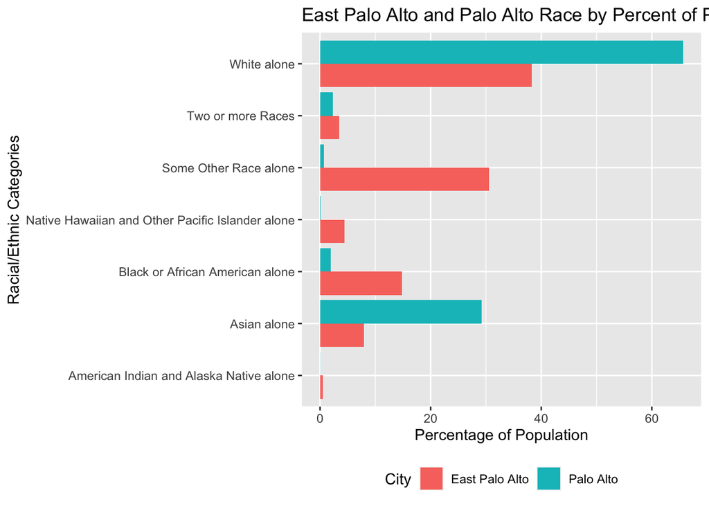

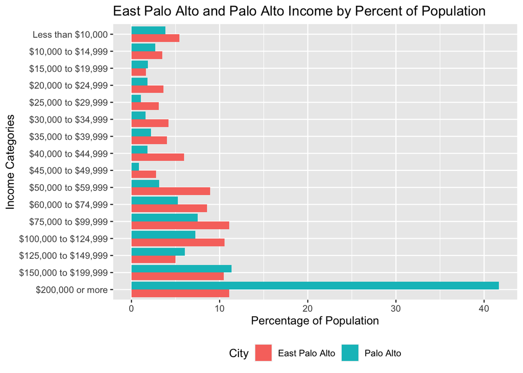

Keeping in mind both of these charts, the combination of racial and income status of East Palo Alto could increase vulnerability regarding drinking water quality due to potential lack of resources and local autonomy. Such characteristics may predispose this community to be taken advantage of by more affluent neighbors or key decision-makers.

Equity Analysis - Income vs. Water Quality (Tract-Level), East Palo Alto vs. Palo Alto

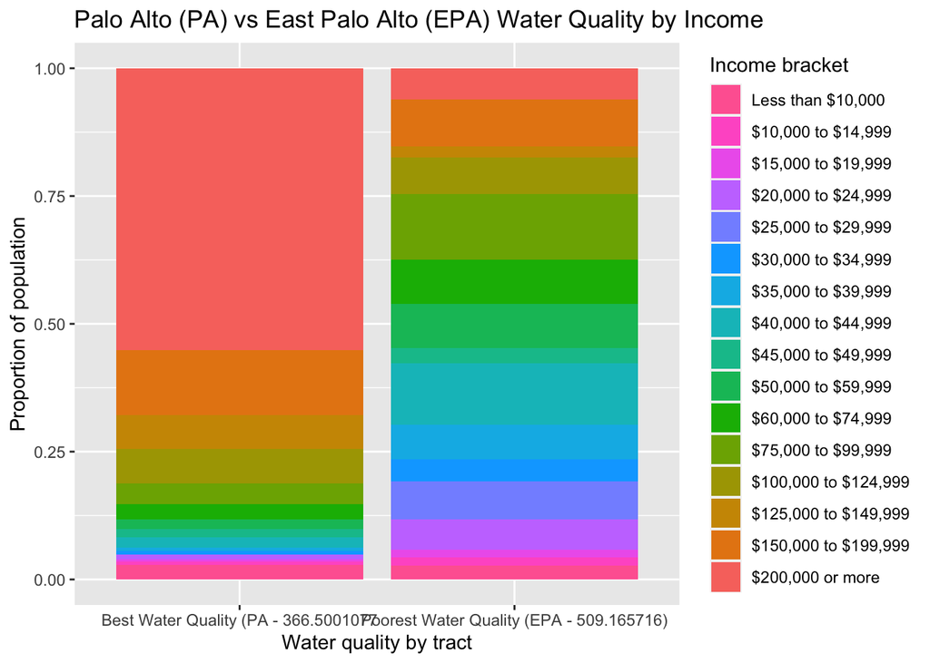

This equity analysis calculates the demographic breakdown of population (proportion of population) in each tract/region of water quality by income. Using the tract in East Palo Alto with the poorest water quality (contaminant level of 509.2) and the tract in Palo Alto with the best water quality (contaminant level of 366.5), we compared the income levels across these two tracts. More significantly, the tract with the best water quality has over half of the population earning $200,000 or more, compared to the roughly 6% of the population in the tract with poorest water quality, indicating a correlation between the two variables.

Equity Analysis - Race vs. Water Quality (Tract-Level), East Palo Alto vs. Palo Alto

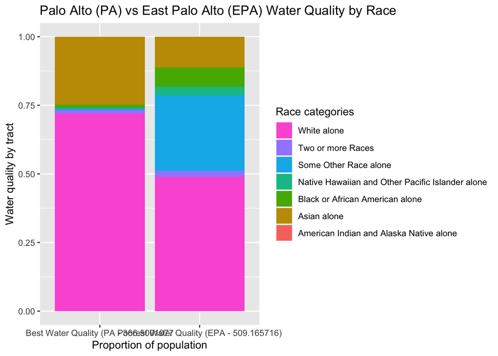

This equity analysis calculates the demographic breakdown of population (proportion of population) in each tract/region of water quality by race. Using the same two tracts in East Palo Alto with the poorest water quality (contaminant level of 509.2) and the tract in Palo Alto with the best water quality (contaminant level of 366.5), we compared the race breakdown across these two tracts. The tract with the best water quality has its White Alone and Asian Alone populations comprising about 97% of the total population; sources and our Census ACS-5 Year data indicate that these two racial categories are generally most affluent in this overal geographic region. Conversely, in the tract with the poorest water quality, the White Alone and Asian Alone population comprises only 60% of the total population. This shows a much higher minority population living in the tract with poorer water quality, again pointing to correlation among variables.

Note: These equity analyses are a response to the constraints of our dataset (discussed later) and, in our opinion, best present our findings. They take the thematic significance of the information in the earlier charts and show it more specifically in terms of drinking water quality (due to the choice of tracts). Additionally, we believe that the aesthetics of the equity analyses illustrate the findings clearly with their color palettes, side-by-side positioning, and labels/legend.

Statistical Analysis - Regressions

```
##
## Call:
## lm(formula = water ~ perc_over100k, data = epa_stat)
##
## Residuals:
##       1       2       3       4
##  45.043  -1.478 -15.281 -28.284
##
## Coefficients:
##               Estimate Std. Error t value Pr(>|t|)
## (Intercept)     663.29      82.61   8.029   0.0152 *
## perc_over100k  -564.14     213.48  -2.643   0.1183
## ---
## Signif. codes:  0 '***' 0.001 '**' 0.01 '*' 0.05 '.' 0.1 ' ' 1
##
## Residual standard error: 39.14 on 2 degrees of freedom
## Multiple R-squared:  0.7774, Adjusted R-squared:  0.666
## F-statistic: 6.983 on 1 and 2 DF,  p-value: 0.1183
```

```
##
## Call:
## lm(formula = water ~ perc_white, data = epa_stat)
##
## Residuals:
##      1      2      3      4
##  65.96 -74.39  46.70 -38.26
##
## Coefficients:
##             Estimate Std. Error t value Pr(>|t|)
## (Intercept)    420.7      168.9   2.491    0.130
## perc_white     143.8      771.5   0.186    0.869
##
## Residual standard error: 82.25 on 2 degrees of freedom
## Multiple R-squared:  0.01708,    Adjusted R-squared:  -0.4744
## F-statistic: 0.03475 on 1 and 2 DF,  p-value: 0.8693
```

```
##
## Call:
## lm(formula = water ~ perc_white + perc_over100k, data = epa_stat)
##
## Residuals:
##       1       2       3       4
##  27.695  11.635  -1.713 -37.617
##
## Coefficients:
##               Estimate Std. Error t value Pr(>|t|)
## (Intercept)      746.1      178.0   4.190    0.149
## perc_white      -278.0      490.9  -0.566    0.672
## perc_over100k   -627.3      285.4  -2.198    0.272
##
## Residual standard error: 48.17 on 1 degrees of freedom
## Multiple R-squared:  0.8314, Adjusted R-squared:  0.4943
## F-statistic: 2.466 on 2 and 1 DF,  p-value: 0.4106
```

For the regressions, we decided to construct new variables for income and race, allowing us to distill the information into one-dimensional measures and analyze them at the tract-level (per city). By re-downloading the Census data and only selecting the variables that we needed, we created percent of population that is white (perc_white) and percent of population earning over $100,000 (perc_over100k) metrics. We then ran single-variable, linear regressions of these two variables with water quality separately before combining the three into a multiple regression. We performed these techniques twice – once for East Palo Alto and once for Palo Alto. In examining these statistical findings, one must remember that the regressions are based on extremely limited data; those for East Palo Alto only consider its four tracts, while those for Palo Alto take into account 13 tracts, many of which possess the same CES4 Drinking Water Quality Score.)

```
##
## Call:
## lm(formula = water ~ perc_over100k, data = pa_stat)
##
## Residuals:
##     Min      1Q  Median      3Q     Max
## -25.794 -16.914  -5.945  18.705  41.990
##
## Coefficients:
##               Estimate Std. Error t value Pr(>|t|)
## (Intercept)     441.31      49.55   8.907 2.32e-06 ***
## perc_over100k   -91.76      73.99  -1.240    0.241
## ---
## Signif. codes:  0 '***' 0.001 '**' 0.01 '*' 0.05 '.' 0.1 ' ' 1
##
## Residual standard error: 22.11 on 11 degrees of freedom
## Multiple R-squared:  0.1227, Adjusted R-squared:  0.0429
## F-statistic: 1.538 on 1 and 11 DF,  p-value: 0.2407
```

```
##
## Call:
## lm(formula = water ~ perc_white, data = pa_stat)
##
## Residuals:
##    Min     1Q Median     3Q    Max
## -18.09 -13.91 -12.02  21.63  48.41
##
## Coefficients:
##             Estimate Std. Error t value Pr(>|t|)
## (Intercept)   362.12      42.64   8.492 3.69e-06 ***
## perc_white     32.69      75.64   0.432    0.674
## ---
## Signif. codes:  0 '***' 0.001 '**' 0.01 '*' 0.05 '.' 0.1 ' ' 1
##
## Residual standard error: 23.4 on 11 degrees of freedom
## Multiple R-squared:  0.0167, Adjusted R-squared:  -0.07269
## F-statistic: 0.1868 on 1 and 11 DF,  p-value: 0.6739
```

```
##
## Call:
## lm(formula = water ~ perc_white + perc_over100k, data = pa_stat)
##
## Residuals:
##     Min      1Q  Median      3Q     Max
## -26.475 -14.116  -6.056  18.646  40.506
##
## Coefficients:
##               Estimate Std. Error t value Pr(>|t|)
## (Intercept)     430.05      73.76   5.831 0.000166 ***
## perc_white       16.36      76.16   0.215 0.834264
## perc_over100k   -88.52      78.88  -1.122 0.287983
## ---
## Signif. codes:  0 '***' 0.001 '**' 0.01 '*' 0.05 '.' 0.1 ' ' 1
##
## Residual standard error: 23.13 on 10 degrees of freedom
## Multiple R-squared:  0.1267, Adjusted R-squared:  -0.04797
## F-statistic: 0.7253 on 2 and 10 DF,  p-value: 0.508
```

Considering the many techniques used in this project and the characteristics of the data, the equity analyses most readily illustrate the information, pointing to correlations between both income and water quality as well as race and water quality. It appears that, in terms of EPA and PA, East Palo Alto possess both a population that is comprised more of minority groups and earns less on average than that of Palo Alto; additionally, East Palo Alto – especially in two of its four Census tracts – experiences more water contamination based on CalEnviroScreen data. Future research could expand the spatial scale of the study to the Bay Area, look to pinpoint the source of the disparities, and use more granular data (potentially that on the level of households).

NOTE

The project aims and the datasets chosen presented unforeseen challenges in our analysis and limitations on the techniques that we could use. CalEnviroScreen data is measured by the tract, and, as a result, we imported tract-level Census ACS-5 year data for income and race (each with estimates for the different financial and ethnical categories). In attempting to directly compare water quality to income or race respectively, we realized that the only way to do so would be to operate on the tract level, as every demographic bucket per tract possessed the same CES4 Drinking Water Quality Score. However, the breakdown of Census data by estimates within specific racial and ethnic groups of a tract impeded this process, as we struggled to calculate an average/indicative income value or distinguish a dominant race per a tract to pair with the Water Quality Score. Due to this constraint, we selected two tracts — one from EPA with the highest (worst) CES4 Score and one from PA with the lowest (best) CES4 Score — and compared the two in equity analyses of Water Quality vs. Income and Water Quality vs. Race. Additionally, we attempted a statistical regression and navigated the issue discussed above by creating new variables based on set standards, such was percent over $100,000 and percent under $25,000 for annual household income as well as percent white and percent non-white for racial/ethnic identity. Here, though, we reached the obstacle of too few data points, as there are a total of 17 tracts (thus, 17 data points in EPA and PA combined). The lack of substantial data hinders the analysis as well as its interpretation. Looking back, we would consider using a different source for water quality values, potentially one with more spatial granularity, and PUMS data, allowing us to examine on the level of individual households, include replicate weights in regressions, and calculate an average income value for a geographic region.